# HOMEWORK 2

Abdullah Aladağ - IE582 - Fall 2020

```r
# Import library

library("ggplot2")
library("tidyverse")
library("dplyr")
library("scatterplot3d")
library("plot3D")
```

```r
# Read data
setwd("C:/Users/asus/Desktop")


X_train = read.table("X_TRAIN.csv")
Y_train = read.table("Y_TRAIN.csv")
Z_train = read.table("Z_TRAIN.csv")
```

## TASK 1

### Task A

In this part, our aim is to visualize one instance(all axes) as 3D scatterplot. We obtain velocity. We can transform this data to velocity vector by computing cumulative sum of acceleration over time.Then, We obtain position vector using velocity vector.

```r
X_velocity = as.data.frame(matrix(,8,ncol(X_train)))
X_position = as.data.frame(matrix(,8,ncol(X_train)))

Y_velocity = as.data.frame(matrix(,8,ncol(Y_train)))
Y_position = as.data.frame(matrix(,8,ncol(Y_train)))

Z_velocity = as.data.frame(matrix(,8,ncol(Z_train)))
Z_position = as.data.frame(matrix(,8,ncol(Z_train)))


for (j in 1:8){

    for (i in 1:nrow(X_train)){

        if( X_train[i,1] == j){

          X_velocity[j,] = cbind(j,matrix(cumsum(as.numeric(X_train[i,-1])),1,ncol(X_train)-1))
          X_position[j,] = cbind(j,matrix(cumsum(as.numeric(X_velocity[j,-1])),1,ncol(X_train)-1))

          Y_velocity[j,] = cbind(j,matrix(cumsum(as.numeric(Y_train[i,-1])),1,ncol(Y_train)-1))
          Y_position[j,] = cbind(j,matrix(cumsum(as.numeric(Y_velocity[j,-1])),1,ncol(Y_train)-1))

          Z_velocity[j,] = cbind(j,matrix(cumsum(as.numeric(Z_train[i,-1])),1,ncol(Z_train)-1))
          Z_position[j,] = cbind(j,matrix(cumsum(as.numeric(Z_velocity[j,-1])),1,ncol(Z_train)-1))
          break
        }


   }
  }
```

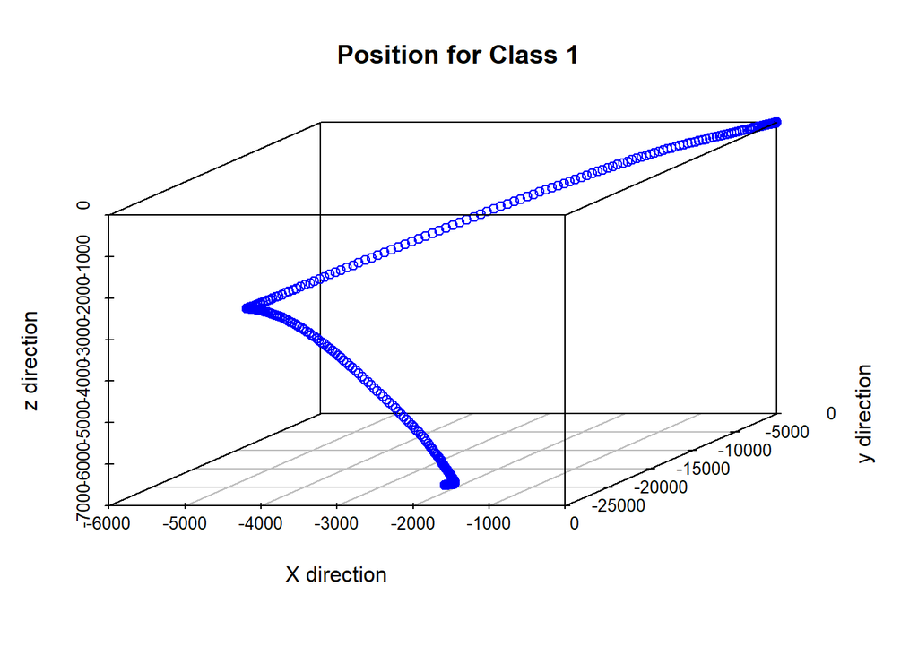

```r
# Visualize position for Class 1

scatterplot3d( as.numeric(X_position[1,-1]), as.numeric(Y_position[1,-1]), as.numeric(Z_position[1,-1]),  color ="Blue", xlab = "X direction", ylab = "y direction",zlab = "z direction", main = "Position for Class 1")
```

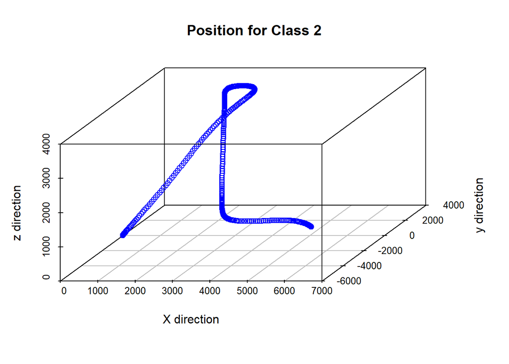

```r
# Visualize position for Class 2
scatterplot3d( as.numeric(X_position[2,-1]), as.numeric(Y_position[2,-1]), as.numeric(Z_position[2,-1]),  color ="Blue",xlab = "X direction", ylab = "y direction",zlab = "z direction", main = "Position for Class 2")
```

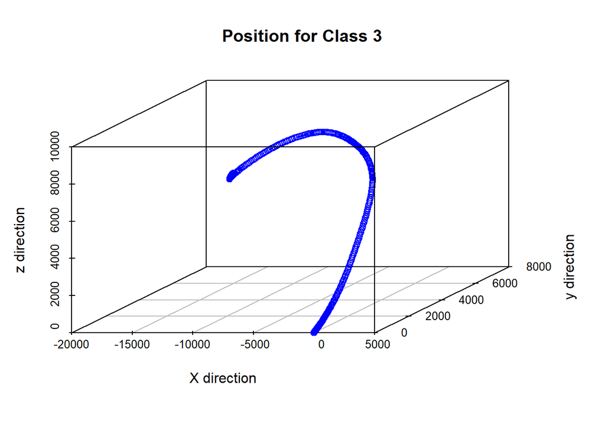

```r
# Visualize position for Class 3
scatterplot3d( as.numeric(X_position[3,-1]), as.numeric(Y_position[3,-1]), as.numeric(Z_position[3,-1]),  color ="Blue",xlab = "X direction", ylab = "y direction",zlab = "z direction", main = "Position for Class 3")
```

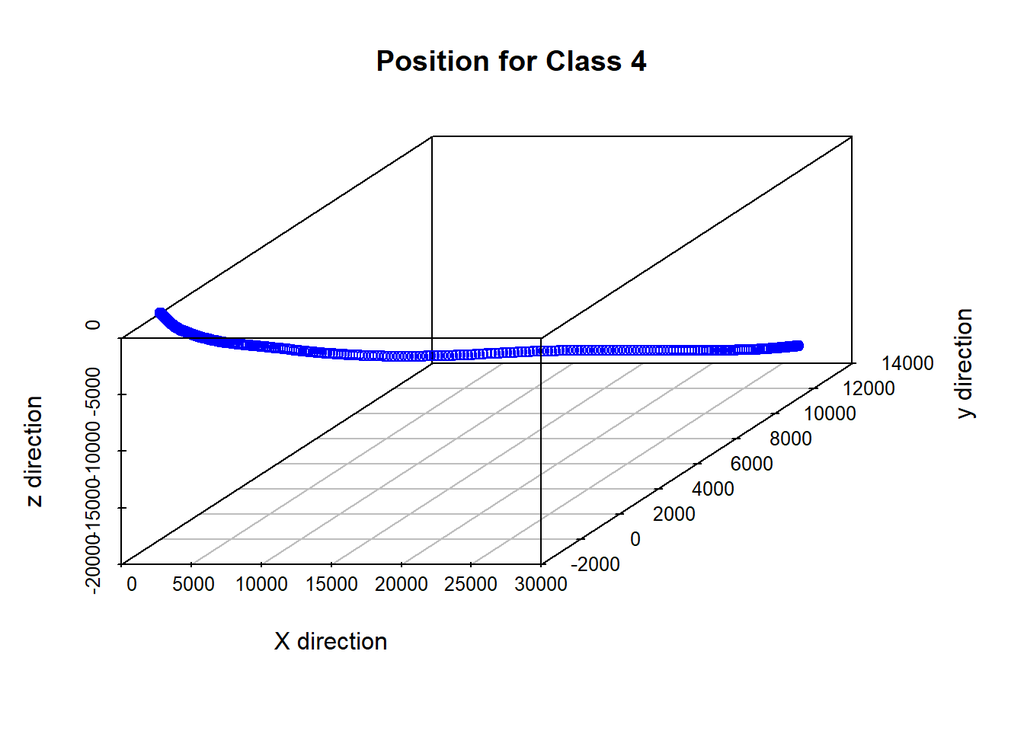

```r
# Visualize position for Class 4

scatterplot3d( as.numeric(X_position[4,-1]), as.numeric(Y_position[4,-1]), as.numeric(Z_position[4,-1]),  color ="Blue",xlab = "X direction", ylab = "y direction",zlab = "z direction", main = "Position for Class 4")
```

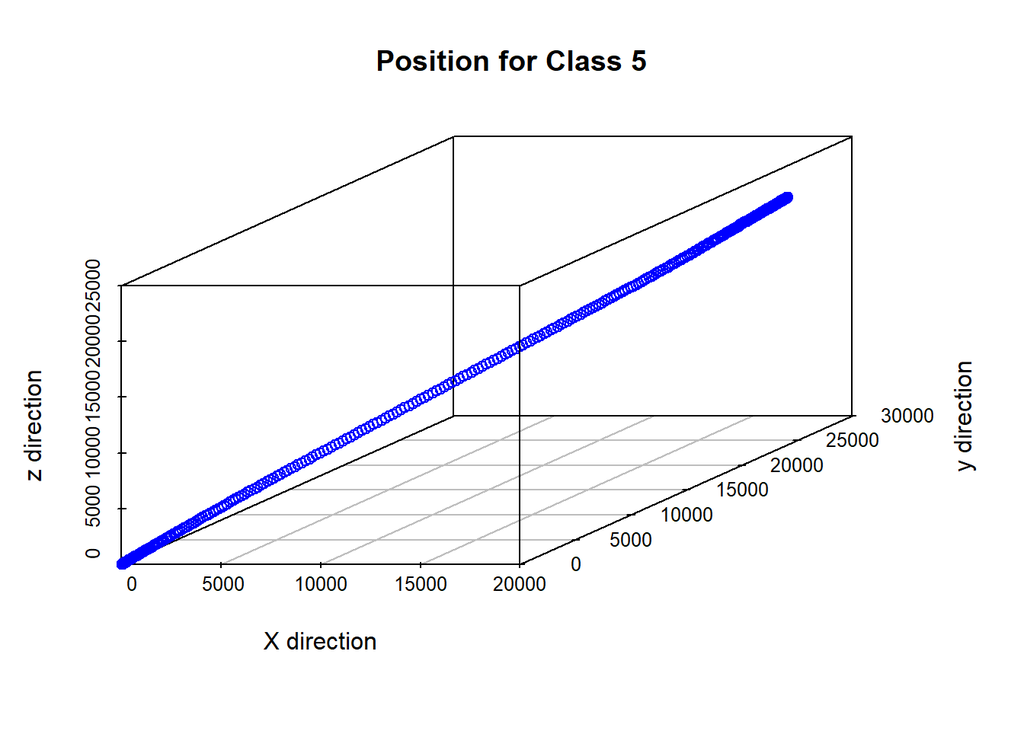

```r
# Visualize position for Class 5

scatterplot3d( as.numeric(X_position[5,-1]), as.numeric(Y_position[5,-1]), as.numeric(Z_position[5,-1]),  color ="Blue",xlab = "X direction", ylab = "y direction",zlab = "z direction", main = "Position for Class 5")
```

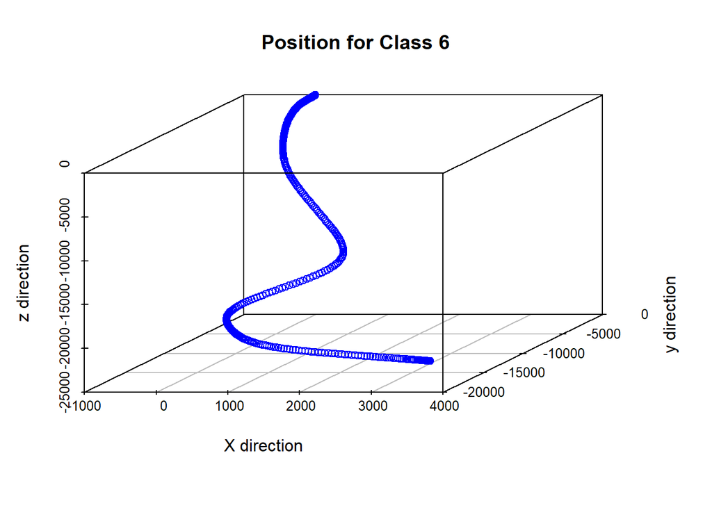

```r
# Visualize position for Class 6

scatterplot3d( as.numeric(X_position[6,-1]), as.numeric(Y_position[6,-1]), as.numeric(Z_position[6,-1]),  color ="Blue",xlab = "X direction", ylab = "y direction",zlab = "z direction", main = "Position for Class 6")
```

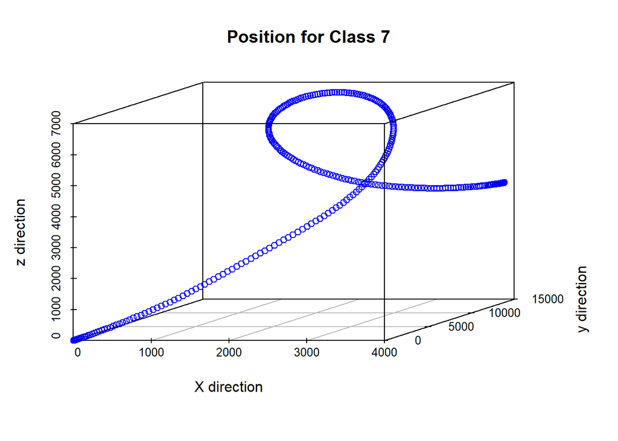

```r
# Visualize position for Class 7

scatterplot3d( as.numeric(X_position[7,-1]), as.numeric(Y_position[7,-1]), as.numeric(Z_position[7,-1]),  color ="Blue",xlab = "X direction", ylab = "y direction",zlab = "z direction", main = "Position for Class 7")
```

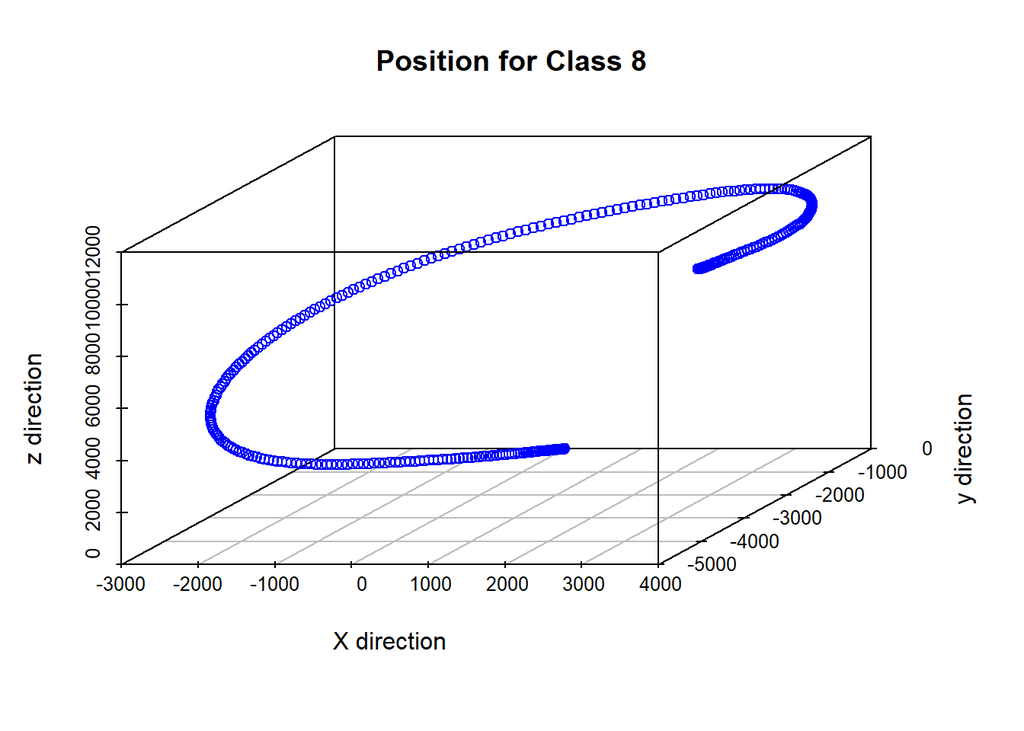

```r
# Visualize position for Class 8

scatterplot3d( as.numeric(X_position[8,-1]), as.numeric(Y_position[8,-1]), as.numeric(Z_position[8,-1]),  color ="Blue",xlab = "X direction", ylab = "y direction",zlab = "z direction", main = "Position for Class 8")
```

There are some similarities between 3D graphs and gestures which are given in homework. Especially, Class 1,4,5,8 are very similar to given gestures.

## Task B

In part B, our aim is to create long format table from given data.Then,We apply PCA to whole data in order to reduce 3D data to 1D.Then, we can select 2 time series from each classes by chance.

```r
colnames(X_train)[1] <- colnames(Y_train)[1] <- colnames(Z_train)[1]  <- "Class"

# Create time ID,index and class
Time_Ind = matrix(rep(matrix(rep(1:(ncol(X_train)-1)),(ncol(X_train)-1),1),nrow(X_train)),nrow(X_train)*(ncol(X_train)-1),1)
Time_ID = matrix(rep(1:nrow(X_train),each = ncol(X_train)-1),nrow(X_train)*(ncol(X_train)-1),1)

Class = as.data.frame(X_train[order(X_train$Class),1])
Class = as.data.frame(rep(Class, each = 315))
Class_long = reshape(Class,direction = "long", v.names = "Class", varying = 1:ncol(Class))
Class_long = as.data.frame(Class_long[order(Class_long$Class),2])
colnames(Class_long) = "Class"

X_train_1 <- reshape(as.data.frame(t(X_train[which(X_train$Class ==1 ),-1])), direction = "long", v.names = "X",varying =1:nrow(X_train[which(X_train$Class == 1),]))[2]

X_train_2 <- reshape(as.data.frame(t(X_train[which(X_train$Class == 2 ),-1])), direction = "long", v.names = "X",varying =1:nrow(X_train[which(X_train$Class == 2),]))[2]

X_train_3 <- reshape(as.data.frame(t(X_train[which(X_train$Class ==3 ),-1])), direction = "long", v.names = "X",varying = 1:nrow(X_train[which(X_train$Class == 3),]))[2]

X_train_4 <- reshape(as.data.frame(t(X_train[which(X_train$Class ==4 ),-1])), direction = "long", v.names = "X",varying =1:nrow(X_train[which(X_train$Class == 4),]))[2]

X_train_5 <- reshape(as.data.frame(t(X_train[which(X_train$Class ==5 ),-1])), direction = "long", v.names = "X",varying =1:nrow(X_train[which(X_train$Class == 5),]))[2]

X_train_6 <- reshape(as.data.frame(t(X_train[which(X_train$Class ==6 ),-1])), direction = "long", v.names = "X",varying =1:nrow(X_train[which(X_train$Class == 6),]))[2]

X_train_7 <- reshape(as.data.frame(t(X_train[which(X_train$Class ==7 ),-1])), direction = "long", v.names = "X",varying =1:nrow(X_train[which(X_train$Class == 7),]))[2]

X_train_8 <- reshape(as.data.frame(t(X_train[which(X_train$Class ==8 ),-1])), direction = "long", v.names = "X",varying =1:nrow(X_train[which(X_train$Class == 8),]))[2]


# combine x into one matrix

X_long <- rbind(X_train_1,X_train_2,X_train_3,X_train_4,X_train_5,X_train_6,X_train_7,X_train_8)
```

```r
# For y

Y_train_1 <- reshape(as.data.frame(t(Y_train[which(Y_train$Class ==1 ),-1])), direction = "long", v.names = "Y",varying =1:nrow(Y_train[which(Y_train$Class == 1),]))[2]

Y_train_2 <- reshape(as.data.frame(t(Y_train[which(Y_train$Class == 2 ),-1])), direction = "long", v.names = "Y",varying =1:nrow(Y_train[which(Y_train$Class == 2),]))[2]

Y_train_3 <- reshape(as.data.frame(t(Y_train[which(Y_train$Class ==3 ),-1])), direction = "long", v.names = "Y",varying = 1:nrow(Y_train[which(Y_train$Class == 3),]))[2]

Y_train_4 <- reshape(as.data.frame(t(Y_train[which(Y_train$Class ==4 ),-1])), direction = "long", v.names = "Y",varying =1:nrow(Y_train[which(Y_train$Class == 4),]))[2]

Y_train_5 <- reshape(as.data.frame(t(Y_train[which(Y_train$Class ==5 ),-1])), direction = "long", v.names = "Y",varying =1:nrow(Y_train[which(Y_train$Class == 5),]))[2]

Y_train_6 <- reshape(as.data.frame(t(Y_train[which(Y_train$Class ==6 ),-1])), direction = "long", v.names = "Y",varying =1:nrow(Y_train[which(Y_train$Class == 6),]))[2]

Y_train_7 <- reshape(as.data.frame(t(Y_train[which(Y_train$Class ==7 ),-1])), direction = "long", v.names = "Y",varying =1:nrow(Y_train[which(Y_train$Class == 7),]))[2]

Y_train_8 <- reshape(as.data.frame(t(Y_train[which(Y_train$Class ==8 ),-1])), direction = "long", v.names = "Y",varying =1:nrow(Y_train[which(Y_train$Class == 8),]))[2]

# combine y into one matrix

Y_long = rbind(Y_train_1,Y_train_2,Y_train_3,Y_train_4,Y_train_5,Y_train_6,Y_train_7,Y_train_8)
```

```r
# For Z

Z_train_1 <- reshape(as.data.frame(t(Z_train[which(Z_train$Class ==1 ),-1])), direction = "long", v.names = "Z",varying =1:nrow(Z_train[which(Z_train$Class == 1),]))[2]

Z_train_2 <- reshape(as.data.frame(t(Z_train[which(Z_train$Class == 2 ),-1])), direction = "long", v.names = "Z",varying =1:nrow(Z_train[which(Z_train$Class == 2),]))[2]

Z_train_3 <- reshape(as.data.frame(t(Z_train[which(Z_train$Class ==3 ),-1])), direction = "long", v.names = "Z",varying = 1:nrow(Z_train[which(Z_train$Class == 3),]))[2]

Z_train_4 <- reshape(as.data.frame(t(Z_train[which(Z_train$Class ==4 ),-1])), direction = "long", v.names = "Z",varying =1:nrow(Z_train[which(Z_train$Class == 4),]))[2]

Z_train_5 <- reshape(as.data.frame(t(Z_train[which(Z_train$Class ==5 ),-1])), direction = "long", v.names = "Z",varying =1:nrow(Z_train[which(Z_train$Class == 5),]))[2]

Z_train_6 <- reshape(as.data.frame(t(Z_train[which(Z_train$Class ==6 ),-1])), direction = "long", v.names = "Z",varying =1:nrow(Z_train[which(Z_train$Class == 6),]))[2]

Z_train_7 <- reshape(as.data.frame(t(Z_train[which(Z_train$Class ==7 ),-1])), direction = "long", v.names = "Z",varying =1:nrow(Z_train[which(Z_train$Class == 7),]))[2]

Z_train_8 <- reshape(as.data.frame(t(Z_train[which(Z_train$Class ==8 ),-1])), direction = "long", v.names = "Z",varying =1:nrow(Z_train[which(Z_train$Class == 8),]))[2]

## combine z into one matrix

Z_long =  rbind(Z_train_1,Z_train_2,Z_train_3,Z_train_4,Z_train_5,Z_train_6,Z_train_7,Z_train_8)
```

```r
# Create long table
alldata_long <- cbind(Time_ID,Time_Ind ,X_long,Y_long,Z_long,Class_long)
head(alldata_long)
```

```
##     Time_ID Time_Ind          X         Y          Z Class
## 1.1       1        1 -0.7914472 -1.959984 -0.2490781     1
## 2.1       1        2 -0.7914472 -1.959984 -0.2490781     1
## 3.1       1        3 -0.7958727 -1.956600 -0.2514390     1
## 4.1       1        4 -0.8100650 -1.945750 -0.2590101     1
## 5.1       1        5 -0.8492300 -1.915809 -0.2799033     1
## 6.1       1        6 -0.9034648 -1.874347 -0.3088358     1
```

```r
# Apply PCA to acceleration data

only_axis_data = alldata_long[,3:5]
pca <- princomp(only_axis_data , cor = TRUE)
summary(pca,loadings = TRUE)
```

```
## Importance of components:
##                          Comp.1    Comp.2    Comp.3
## Standard deviation     1.213171 1.0198583 0.6986445
## Proportion of Variance 0.490595 0.3467037 0.1627014
## Cumulative Proportion  0.490595 0.8372986 1.0000000
##
## Loadings:
##   Comp.1 Comp.2 Comp.3
## X  0.427  0.776  0.464
## Y  0.721        -0.692
## Z  0.546 -0.630  0.553
```

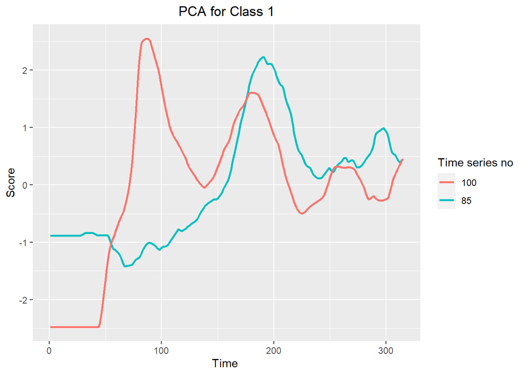

```r
# For Class 1

Pca_data = as.data.frame(pca$scores)
Pca_data$TimeID = Time_ID
Pca_data$Class = Class_long

drop = c("Comp.2","Comp.3")
Component_1 = Pca_data[,!(names(Pca_data) %in% drop)]

time = c(1:315)

ts_1.1 <- Component_1[which(Component_1$Class == 1 & Component_1$TimeID == 100),]
ts_1.2 <- Component_1[which(Component_1$Class == 1 & Component_1$TimeID == 85),]

ggplot()+geom_line(data=ts_1.1,aes(x=time,y=Comp.1,colour="yellow"), size=1 )+
          geom_line(data=ts_1.2,aes(x=time,y=Comp.1,colour="red"),size=1) +
          scale_color_discrete(name = "Time series no", labels = c("100", "85"))+xlab("Time ")+
          ylab("Score")+ggtitle("PCA for Class 1")+theme(plot.title = element_text(hjust = 0.5))
```

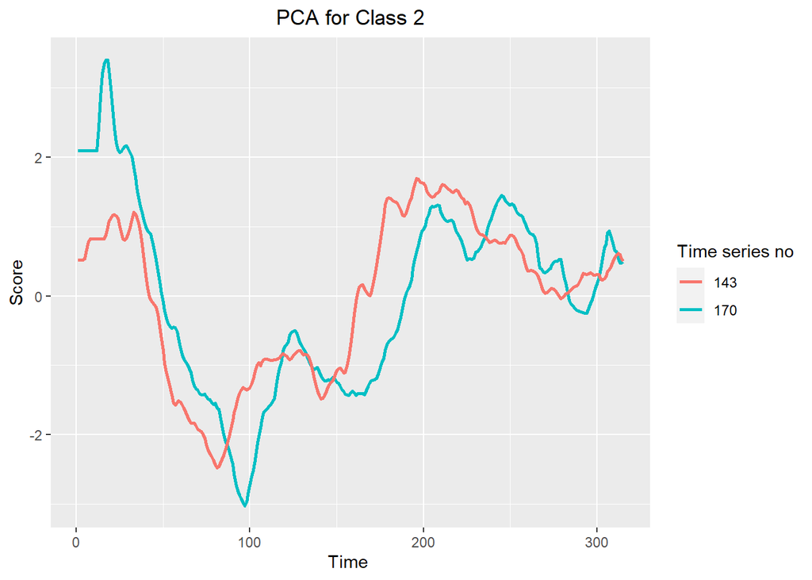

```r
# For class 2

ts_2.1 <- Component_1[which(Component_1$Class == 2 & Component_1$TimeID == 143),]
ts_2.2 <- Component_1[which(Component_1$Class == 2 & Component_1$TimeID == 170),]

ggplot()+geom_line(data=ts_2.1,aes(x=time,y=Comp.1,colour="green"), size=1 )+
  geom_line(data=ts_2.2,aes(x=time,y=Comp.1,colour="blue"),size=1) +
  scale_color_discrete(name = "Time series no", labels = c("143", "170"))+xlab("Time ")+
  ylab("Score")+ggtitle("PCA for Class 2")+ theme(plot.title = element_text(hjust=0.5))
```

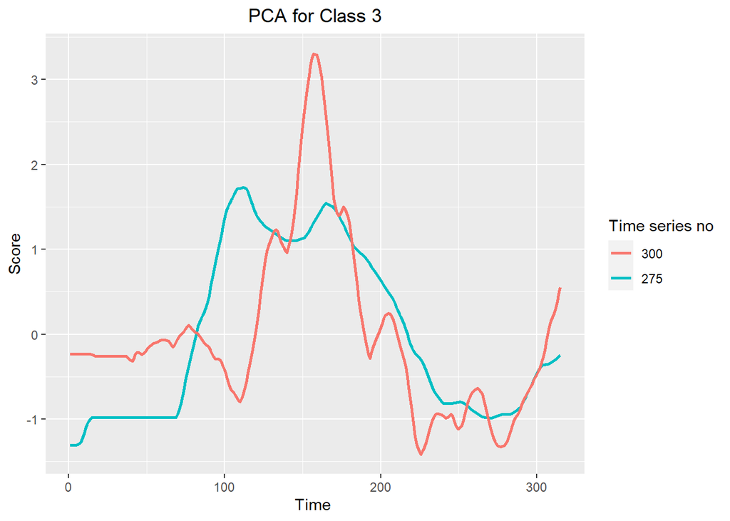

```r
# For class 3

ts_3.1 <- Component_1[which(Component_1$Class == 3 & Component_1$TimeID == 300),]
ts_3.2 <- Component_1[which(Component_1$Class == 3 & Component_1$TimeID == 275),]

ggplot()+geom_line(data=ts_3.1,aes(x=time,y=Comp.1,colour="green"), size=1 )+
  geom_line(data=ts_3.2,aes(x=time,y=Comp.1,colour="blue"),size=1) +
  scale_color_discrete(name = "Time series no", labels = c("300", "275"))+xlab("Time ")+
  ylab("Score")+ggtitle("PCA for Class 3")+theme(plot.title = element_text(hjust = 0.5))
```

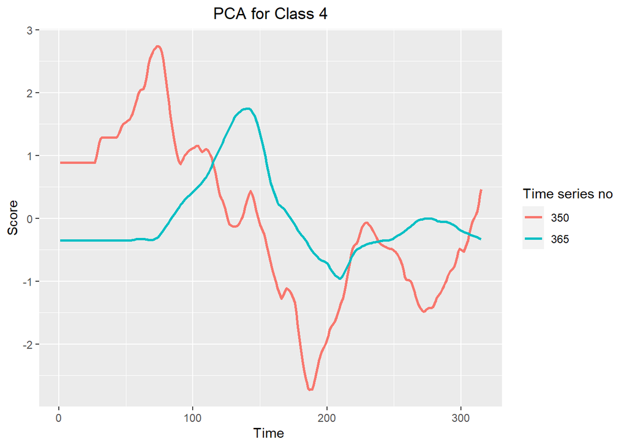

```r
# For class 4

ts_4.1 <- Component_1[which(Component_1$Class == 4 & Component_1$TimeID == 350),]
ts_4.2 <- Component_1[which(Component_1$Class == 4 & Component_1$TimeID == 365),]

ggplot()+geom_line(data=ts_4.1,aes(x=time,y=Comp.1,colour="darkred"), size=1 )+
  geom_line(data=ts_4.2,aes(x=time,y=Comp.1,colour="steelblue"),size=1) +
  scale_color_discrete(name = "Time series no", labels = c("350", "365"))+xlab("Time ")+
  ylab("Score")+ggtitle("PCA for Class 4")+theme(plot.title = element_text(hjust = 0.5))
```

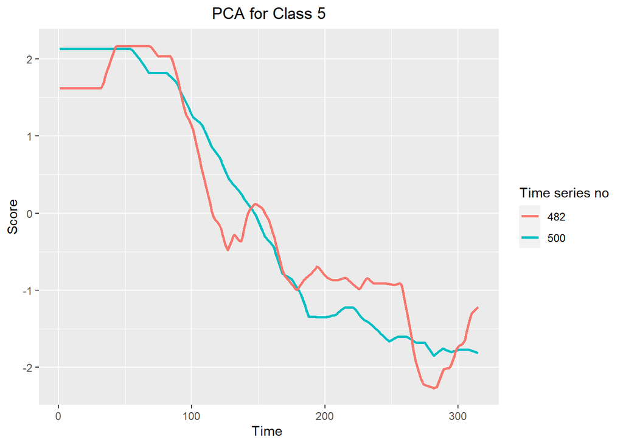

```r
# For class 5

ts_5.1 <- Component_1[which(Component_1$Class == 5 & Component_1$TimeID == 482),]
ts_5.2 <- Component_1[which(Component_1$Class == 5 & Component_1$TimeID == 500),]

ggplot()+geom_line(data=ts_5.1,aes(x=time,y=Comp.1,colour="green"), size=1 )+
  geom_line(data=ts_5.2,aes(x=time,y=Comp.1,colour="blue"),size=1) +
  scale_color_discrete(name = "Time series no", labels = c("482", "500"))+xlab("Time ")+
  ylab("Score")+ggtitle("PCA for Class 5")+theme(plot.title = element_text(hjust = 0.5))
```

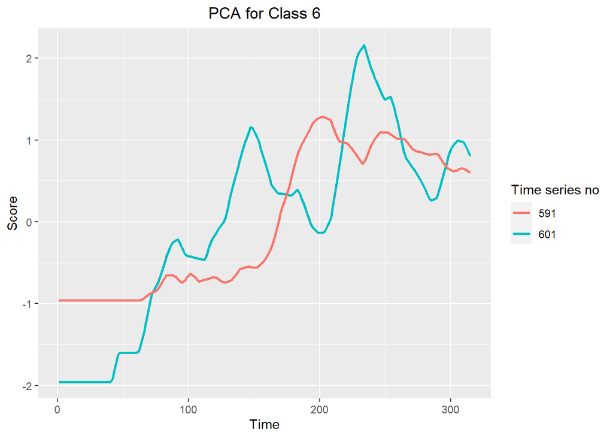

```r
# For class 6

ts_6.1 <- Component_1[which(Component_1$Class == 6 & Component_1$TimeID == 591),]
ts_6.2 <- Component_1[which(Component_1$Class == 6 & Component_1$TimeID == 601),]

ggplot()+geom_line(data=ts_6.1,aes(x=time,y=Comp.1,colour="green"), size=1 )+
  geom_line(data=ts_6.2,aes(x=time,y=Comp.1,colour="blue"),size=1) +
  scale_color_discrete(name = "Time series no", labels = c("591", "601"))+xlab("Time")+
  ylab("Score")+ggtitle("PCA for Class 6")+theme(plot.title = element_text(hjust = 0.5))
```

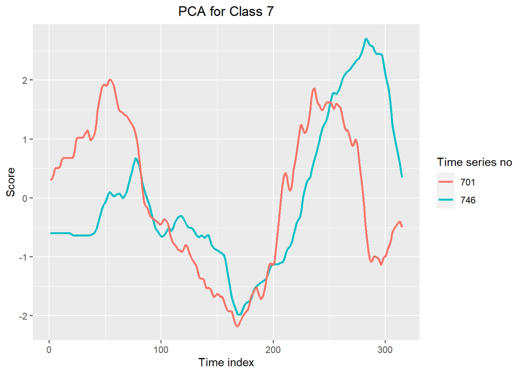

```r
# For class 7

ts_7.1 <- Component_1[which(Component_1$Class == 7 & Component_1$TimeID == 701),]
ts_7.2 <- Component_1[which(Component_1$Class == 7 & Component_1$TimeID == 746),]

ggplot()+geom_line(data=ts_7.1,aes(x=time,y=Comp.1,colour="green"), size=1 )+
  geom_line(data=ts_7.2,aes(x=time,y=Comp.1,colour="blue"),size=1) +
  scale_color_discrete(name = "Time series no", labels = c("701", "746"))+xlab("Time index")+
  ylab("Score")+ggtitle("PCA for Class 7")+theme(plot.title = element_text(hjust = 0.5))
```

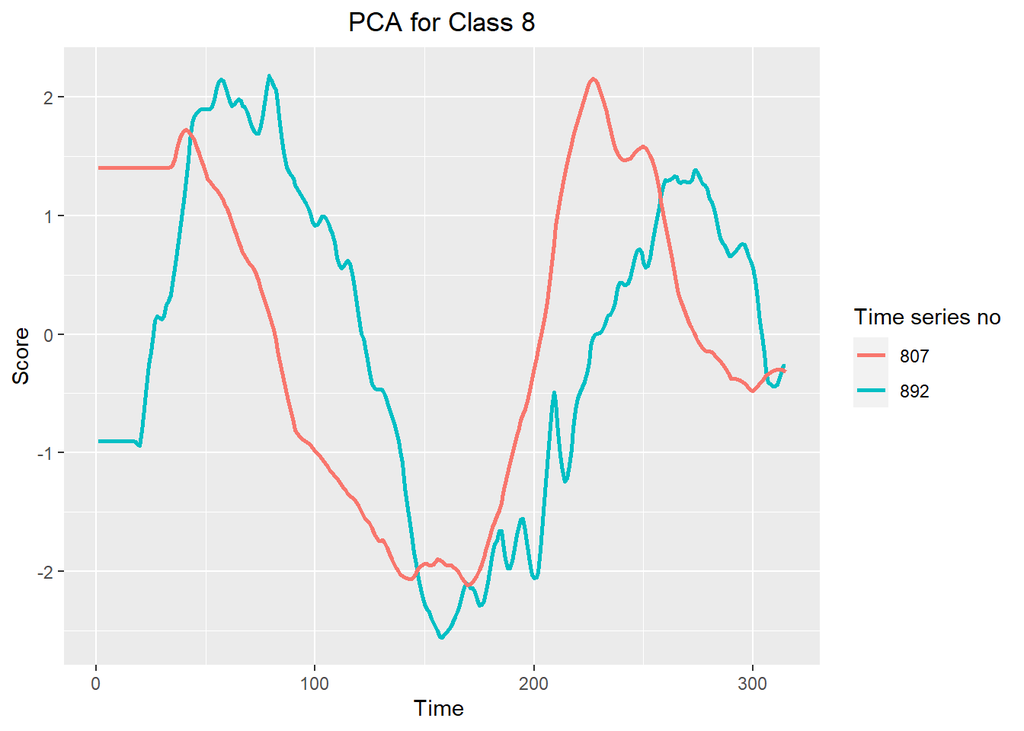

```r
# For class 8

ts_8.1 <- Component_1[which(Component_1$Class == 8 & Component_1$TimeID == 807),]
ts_8.2 <- Component_1[which(Component_1$Class == 8 & Component_1$TimeID == 892),]

ggplot()+geom_line(data=ts_8.1,aes(x=time,y=Comp.1,colour="green"), size=1 )+
  geom_line(data=ts_8.2,aes(x=time,y=Comp.1,colour="blue"),size=1) +
  scale_color_discrete(name = "Time series no", labels = c("807", "892"))+xlab("Time ")+
  ylab("Score")+ggtitle("PCA for Class 8")+theme(plot.title = element_text(hjust = 0.5))
```

According to PCA, component 1 has best values to show this data as 1D.Proportion of variance means that how much data this component use. Proportion of variance of component1 is equal to 0.49 which is the highest value among components.Therefore,component1 is used. When we visiualize data, it is possible to see that classes have different pattern.Thus, we can separate classes looking at graphs in reduced dimensions.

### Task C

```r
# Class1

Data_1 <- alldata_long %>% filter(Class == 1)

PCA_1 <- princomp(Data_1[,3:5], cor = T)
summary(PCA_1,loadings = TRUE)
```

```
## Importance of components:
##                           Comp.1    Comp.2    Comp.3
## Standard deviation     1.1779640 0.9845807 0.8018738
## Proportion of Variance 0.4625331 0.3231331 0.2143339
## Cumulative Proportion  0.4625331 0.7856661 1.0000000
##
## Loadings:
##   Comp.1 Comp.2 Comp.3
## X  0.357  0.896  0.263
## Y  0.691        -0.720
## Z  0.629 -0.439  0.642
```

```r
# Class2

Data_2 <- alldata_long %>% filter(Class == 2)

PCA_2 <- princomp(Data_2[,3:5], cor = T)
summary(PCA_2,loadings = TRUE)
```

```
## Importance of components:
##                           Comp.1    Comp.2    Comp.3
## Standard deviation     1.2400176 0.9682706 0.7244366
## Proportion of Variance 0.5125479 0.3125160 0.1749361
## Cumulative Proportion  0.5125479 0.8250639 1.0000000
##
## Loadings:
##   Comp.1 Comp.2 Comp.3
## X  0.455  0.801  0.388
## Y  0.685        -0.728
## Z  0.569 -0.597  0.565
```

```r
# Class3

Data_3 <- alldata_long %>% filter(Class == 3)

PCA_3 <- princomp(Data_3[,3:5], cor = T)
summary(PCA_3,loadings = TRUE)
```

```
## Importance of components:
##                          Comp.1    Comp.2    Comp.3
## Standard deviation     1.273669 0.9475424 0.6927707
## Proportion of Variance 0.540744 0.2992789 0.1599771
## Cumulative Proportion  0.540744 0.8400229 1.0000000
##
## Loadings:
##   Comp.1 Comp.2 Comp.3
## X  0.675         0.738
## Y  0.531  0.689 -0.494
## Z -0.513  0.725  0.460
```

```r
# Class4

Data_4 <- alldata_long %>% filter(Class == 4)

PCA_4 <- princomp(Data_4[,3:5], cor = T)
summary(PCA_4,loadings = TRUE)
```

```
## Importance of components:
##                           Comp.1    Comp.2    Comp.3
## Standard deviation     1.2846735 0.9605566 0.6534102
## Proportion of Variance 0.5501287 0.3075563 0.1423150
## Cumulative Proportion  0.5501287 0.8576850 1.0000000
##
## Loadings:
##   Comp.1 Comp.2 Comp.3
## X  0.681  0.113  0.724
## Y  0.634  0.404 -0.659
## Z -0.367  0.908  0.204
```

```r
# Class5

Data_5 <- alldata_long %>% filter(Class == 5)

PCA_5 <- princomp(Data_5[,3:5], cor = T)
summary(PCA_5,loadings = TRUE)
```

```
## Importance of components:
##                           Comp.1    Comp.2     Comp.3
## Standard deviation     1.3934383 0.9076507 0.48425204
## Proportion of Variance 0.6472234 0.2746099 0.07816668
## Cumulative Proportion  0.6472234 0.9218333 1.00000000
##
## Loadings:
##   Comp.1 Comp.2 Comp.3
## X  0.399  0.915
## Y  0.643 -0.321  0.696
## Z  0.654 -0.243 -0.716
```

```r
# Class6

Data_6 <- alldata_long %>% filter(Class == 6)

PCA_6 <- princomp(Data_6[,3:5], cor = T)
summary(PCA_6,loadings = TRUE)
```

```
## Importance of components:
##                           Comp.1    Comp.2     Comp.3
## Standard deviation     1.3097601 0.9941695 0.54420161
## Proportion of Variance 0.5718239 0.3294577 0.09871846
## Cumulative Proportion  0.5718239 0.9012815 1.00000000
##
## Loadings:
##   Comp.1 Comp.2 Comp.3
## X  0.206  0.964  0.167
## Y -0.680  0.264 -0.684
## Z -0.704         0.710
```

```r
# Class7

Data_7 <- alldata_long %>% filter(Class == 7)

PCA_7 <- princomp(Data_7[,3:5], cor = T)
summary(PCA_7,loadings = TRUE)
```

```
## Importance of components:
##                           Comp.1    Comp.2    Comp.3
## Standard deviation     1.2480424 1.0144419 0.6428823
## Proportion of Variance 0.5192033 0.3430308 0.1377659
## Cumulative Proportion  0.5192033 0.8622341 1.0000000
##
## Loadings:
##   Comp.1 Comp.2 Comp.3
## X  0.229  0.925  0.304
## Y  0.715        -0.697
## Z  0.661 -0.377  0.649
```

```r
# Class8

Data_8 <- alldata_long %>% filter(Class == 8)

PCA_8 <- princomp(Data_2[,3:5], cor = T)
summary(PCA_8,loadings = TRUE)
```

```
## Importance of components:
##                           Comp.1    Comp.2    Comp.3
## Standard deviation     1.2400176 0.9682706 0.7244366
## Proportion of Variance 0.5125479 0.3125160 0.1749361
## Cumulative Proportion  0.5125479 0.8250639 1.0000000
##
## Loadings:
##   Comp.1 Comp.2 Comp.3
## X  0.455  0.801  0.388
## Y  0.685        -0.728
## Z  0.569 -0.597  0.565
```

### Task D

In this part, our aim is to compute the distance between the time series for each axis and then apply MDS to distance matrix in order to examine whether classes are separated or not when we visualize data as distance matrix.

```r
dist <- dist(X_train[,2:ncol(X_train)], method = "euclidean") + dist(Y_train[,2:ncol(Y_train)], method = "euclidean") +
          dist(Z_train[,2:ncol(Z_train)], method = "euclidean")

MDS <- cmdscale(dist,eig = TRUE, k=2)

MDS <- as.data.frame(cbind(X_train[,1],MDS$points))
col = as.factor(MDS$V1)
```

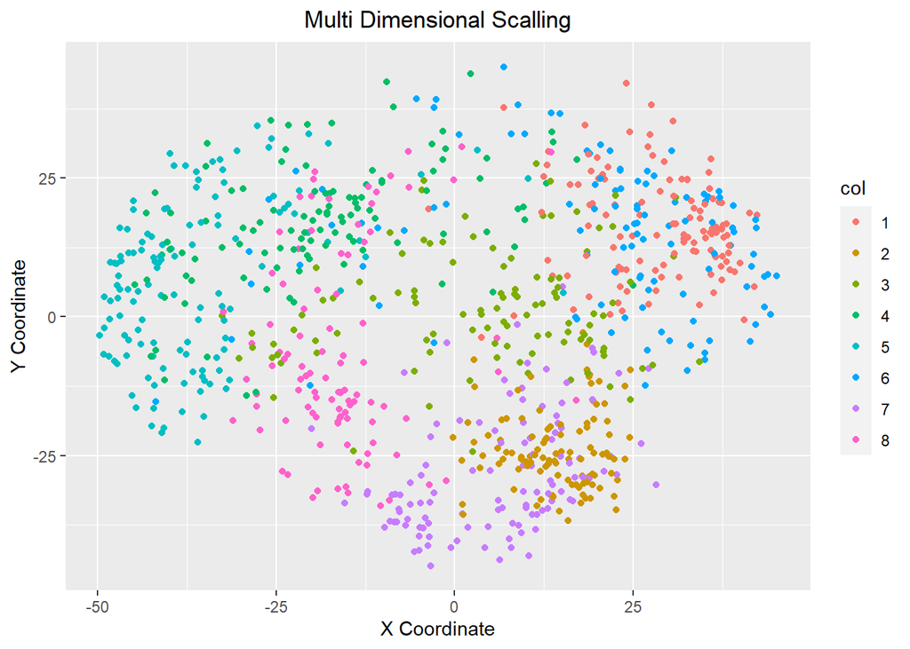

```r
ggplot(data = MDS)+geom_point(mapping = aes(x = V2,y = V3,colour=col))+
  xlab("X Coordinate")+ylab("Y Coordinate")+ ggtitle("Multi Dimensional Scalling")+theme(legend.position = "right")+ theme(plot.title = element_text(hjust=0.5))
```

There is no clear distinction among classes when we visualize distance matrix applied MDS but it is safe to say that some points belonging to same class are clustered in certain regions.